# Lesson 5

### Multivariate Data

We are going to talk about how to examine 3 or more variables at a time

### Third Qualitative Variable

Trying to add a third variable to understand better about the relationships.

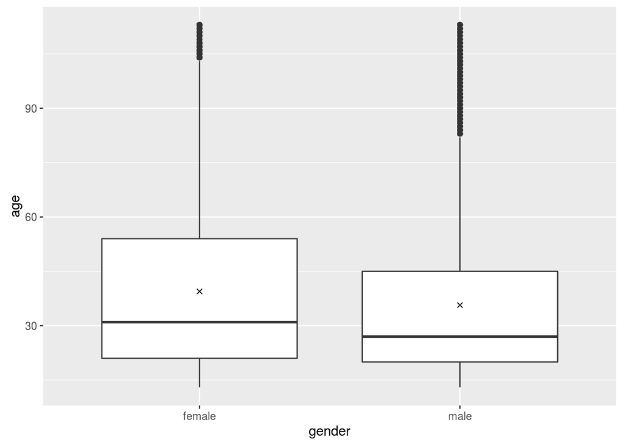

```r
library(ggplot2)

pf <- read.csv("../pseudo_facebook.tsv", sep = "\t",  stringsAsFactors=FALSE)

ggplot(aes(x = gender, y = age),
       data = subset(pf, !is.na(gender))) + geom_boxplot() +
  stat_summary(fun.y = mean, geom = 'point', shape = 4)
```

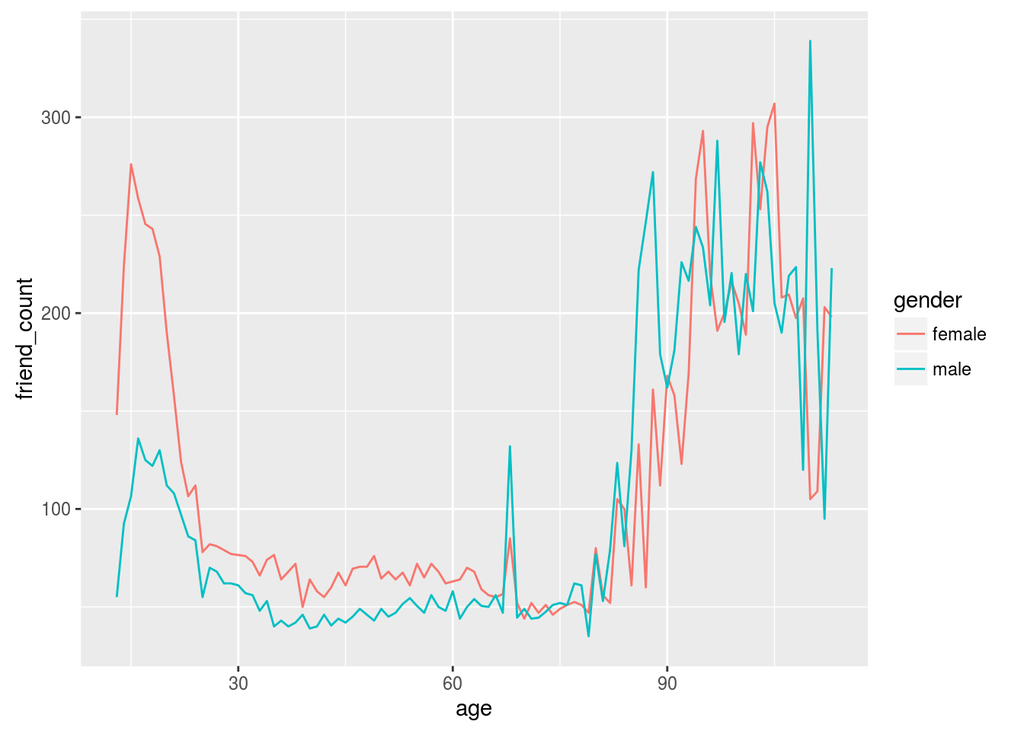

```r
ggplot(aes(x = age, y = friend_count),
       data = subset(pf, !is.na(gender))) +
  geom_line(aes(color = gender), stat = 'summary', fun.y = median)
```

Trying to re-create the same plot by creating the data frame using the `dplyr` package

```r
library(dplyr)
pf.fc_by_age_and_gender <- pf %>%
  filter(!is.na(gender)) %>%
  group_by(age, gender) %>%
  summarise(mean_friend_count = mean(friend_count),
            median_friend_count = median(friend_count),
            n = n()) %>%
  ungroup() %>%
  arrange(age)

head(pf.fc_by_age_and_gender)
```

```
## # A tibble: 6 x 5
##     age gender mean_friend_count median_friend_count     n
##   <int>  <chr>             <dbl>               <dbl> <int>
## 1    13 female          259.1606               148.0   193
## 2    13   male          102.1340                55.0   291
## 3    14 female          362.4286               224.0   847
## 4    14   male          164.1456                92.5  1078
## 5    15 female          538.6813               276.0  1139
## 6    15   male          200.6658               106.5  1478
```

### Plotting Conditional Summaries

Making the same plot as earlier using the new data frame which we created just now.

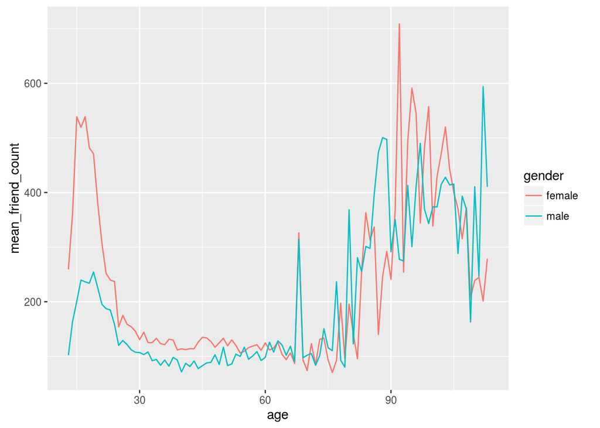

```r
ggplot(
  aes(x = age, y = mean_friend_count, color = gender),
  data = pf.fc_by_age_and_gender
) + geom_line()
```

### Thinking in Ratios

Having graphs comparing 2 things is great but what if we want to have get a handle on how much is the difference. Let’s think in terms of the times of each other.

### Wide and Long Format

Notes:

### Reshaping Data

Changing format of data so that we have age wise male/female median friend count

```r
library(reshape2)
pf.fc_by_age_and_gender.wide <- dcast(pf.fc_by_age_and_gender,
                                      age ~ gender,
                                      value.var = 'median_friend_count')
```

### Ratio Plot

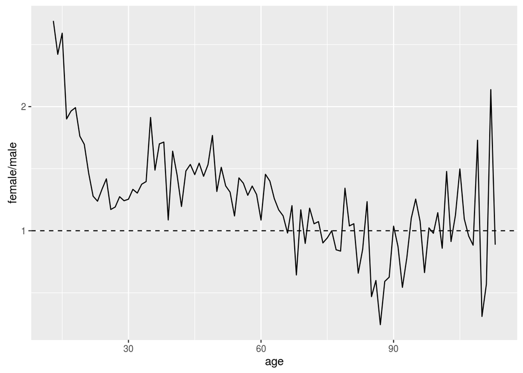

```r
ggplot(
    aes(x = age, y = female/male),
    data = pf.fc_by_age_and_gender.wide
) + geom_line() + geom_hline(yintercept = 1, linetype = 2)
```

### Third Quantitative Variable

Need to add year joined to the original data frame

```r
pf$year_joined <- floor(2014 - pf$tenure/365)
```

### Cut a Variable

Making buckets out of year joined so that each bucket contain comparable number of users

```r
pf$year_joined.bucket <- cut(pf$year_joined, breaks = c(2004, 2009, 2011, 2012, 2014))
```

### Plotting it All Together

Adding a plot for the various tenure bucket vs age to see median friend count

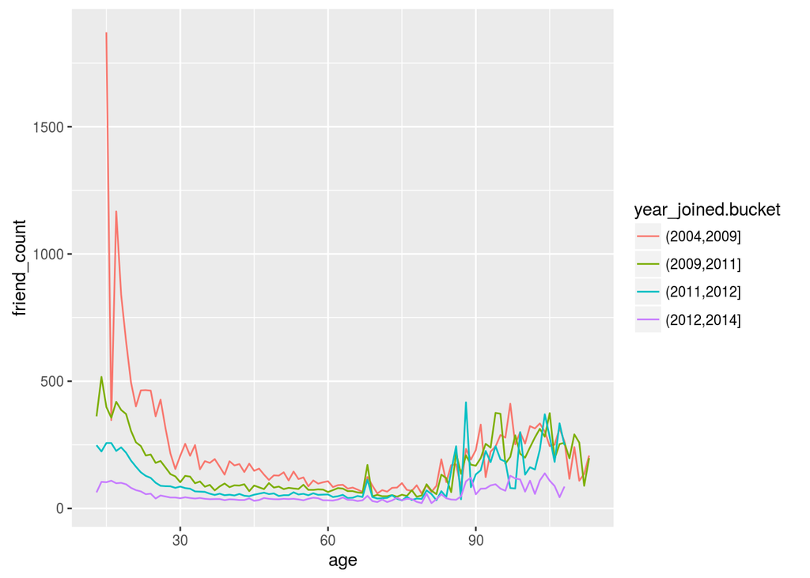

```r
ggplot(aes(x = age, y = friend_count),
       data = subset(pf, !is.na(year_joined.bucket))) +
  geom_line(aes(color = year_joined.bucket), stat = 'summary', fun.y = median)
```

### Plot the Grand Mean

Changing the plot to use mean instead of median. Also want to add overall mean to this as well.

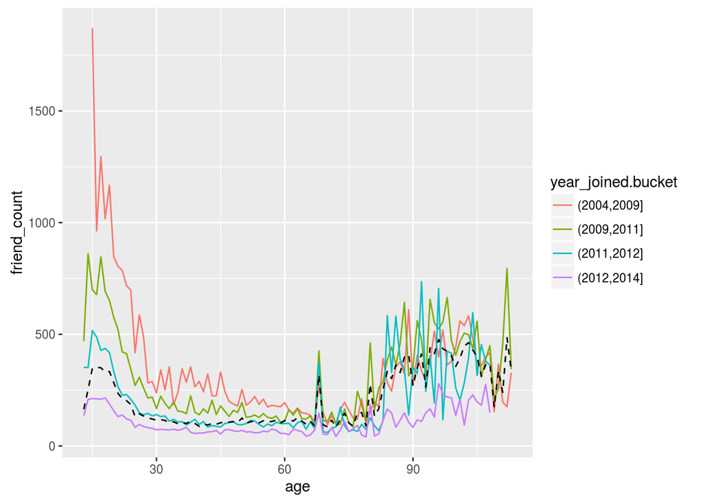

```r
ggplot(aes(x = age, y = friend_count),
       data = subset(pf, !is.na(year_joined.bucket))) +
  geom_line(aes(color = year_joined.bucket), stat = 'summary', fun.y = mean) +
  geom_line(stat = 'summary', fun.y = mean, linetype = 2)
```

### Friending Rate

We want to consider at what rate do people make friends

```r
with(subset(pf, tenure >= 1), summary(friend_count/tenure))
```

```
##     Min.  1st Qu.   Median     Mean  3rd Qu.     Max.
##   0.0000   0.0775   0.2205   0.6096   0.5658 417.0000
```

What is the median friend rate? 0.2205

What is the maximum friend rate? 417.0000

### Friendships Initiated

Do new users go on friending sprees or do old users do this?

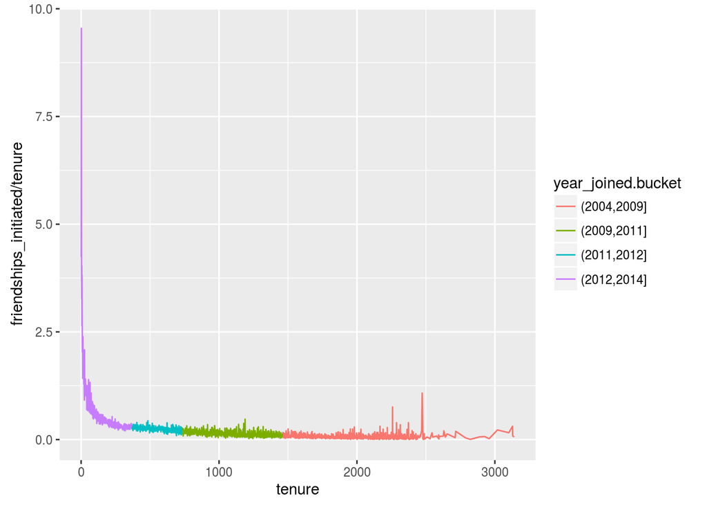

```r
ggplot(aes(x = tenure, y = friendships_initiated / tenure),
       data = subset(pf, !is.na(year_joined.bucket) & tenure >= 1)) +
    geom_line(aes(color = year_joined.bucket), stat = 'summary', fun.y = mean)
```

### Bias-Variance Tradeoff Revisited

Trying to make the graph smoother. Using rounding and smoother

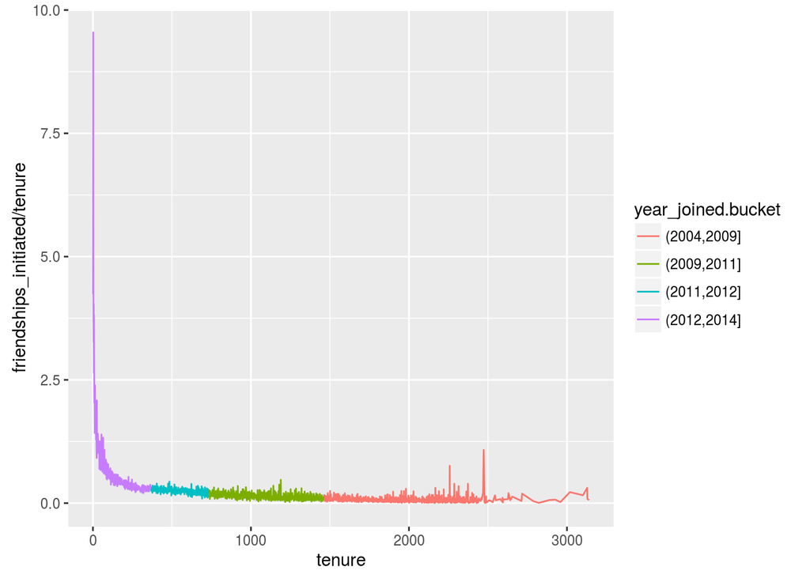

```r
ggplot(aes(x = tenure, y = friendships_initiated / tenure),
       data = subset(pf, tenure >= 1)) +
  geom_line(aes(color = year_joined.bucket),
            stat = 'summary',
            fun.y = mean)
```

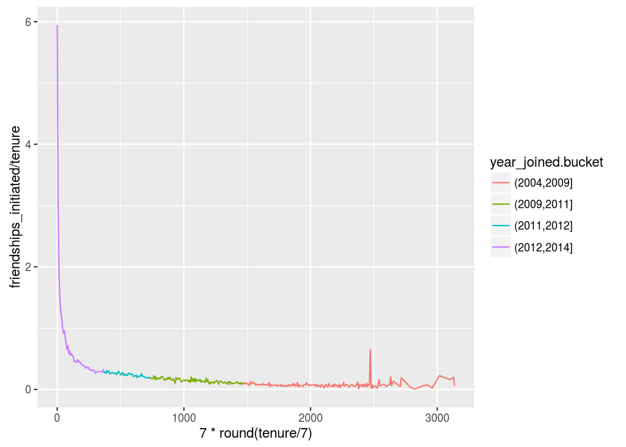

```r
ggplot(aes(x = 7 * round(tenure / 7), y = friendships_initiated / tenure),
       data = subset(pf, tenure > 0)) +
  geom_line(aes(color = year_joined.bucket),
            stat = "summary",
            fun.y = mean)
```

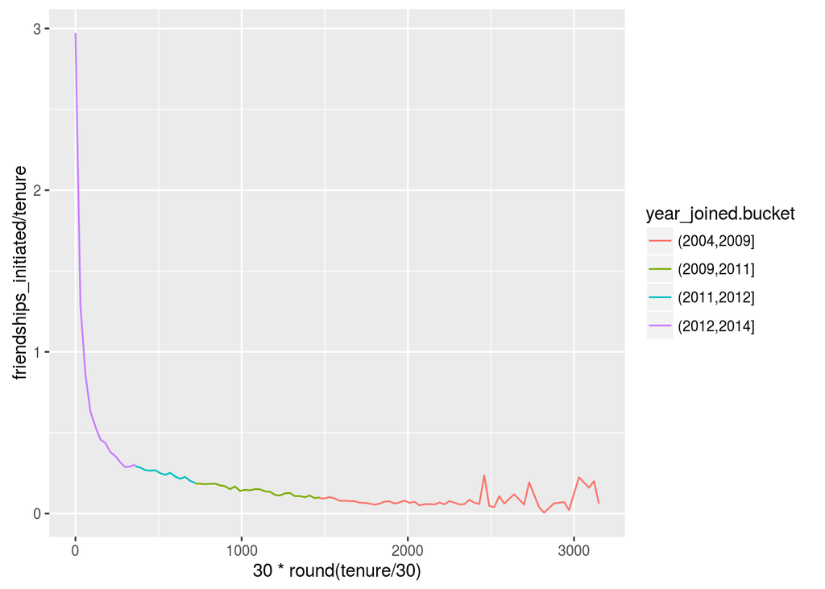

```r
ggplot(aes(x = 30 * round(tenure / 30), y = friendships_initiated / tenure),
       data = subset(pf, tenure > 0)) +
  geom_line(aes(color = year_joined.bucket),
            stat = "summary",
            fun.y = mean)
```

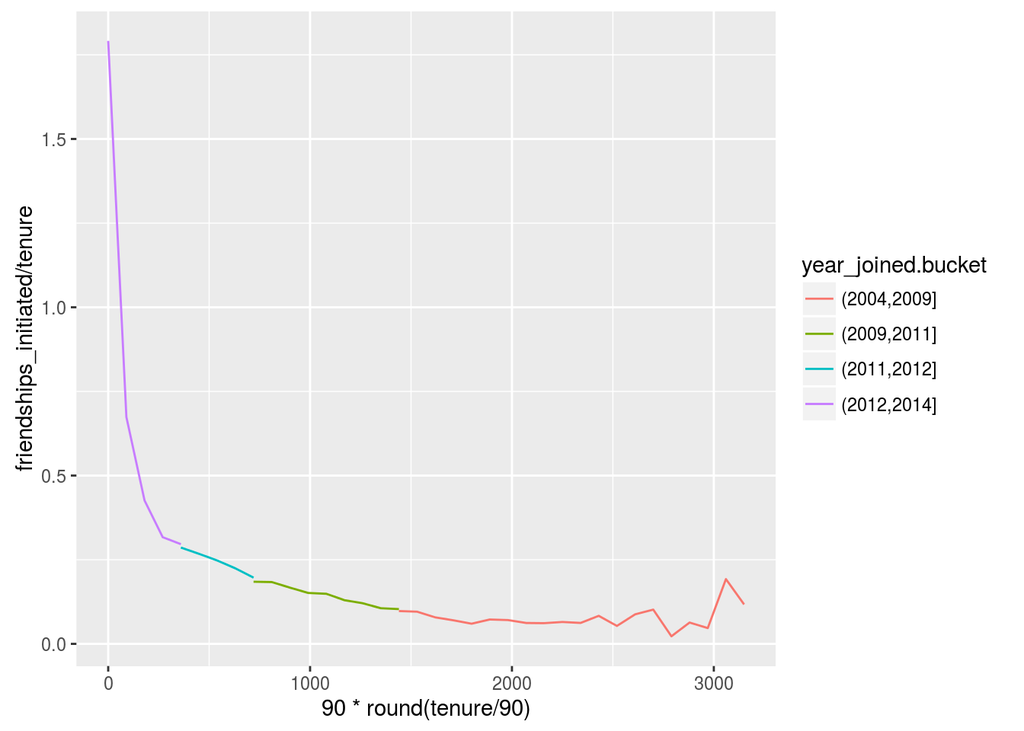

```r
ggplot(aes(x = 90 * round(tenure / 90), y = friendships_initiated / tenure),
       data = subset(pf, tenure > 0)) +
  geom_line(aes(color = year_joined.bucket),
            stat = "summary",
            fun.y = mean)
```

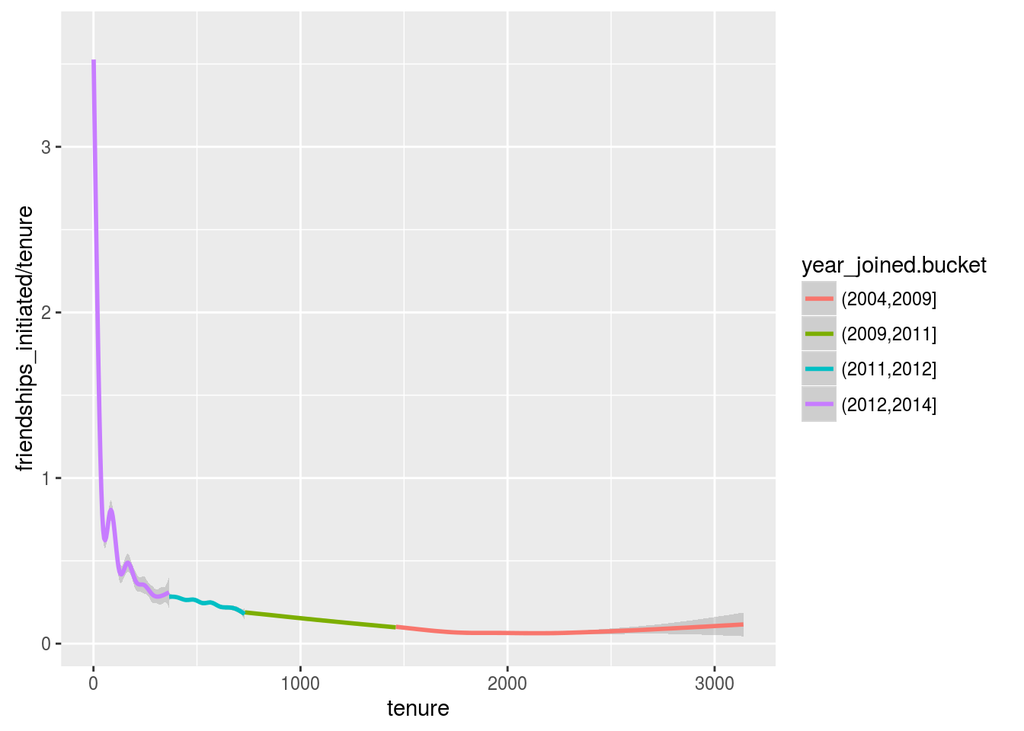

```r
ggplot(aes(x = tenure, y = friendships_initiated / tenure),
       data = subset(pf, tenure >= 1)) +
  geom_smooth(aes(color = year_joined.bucket))
```

### Sean’s NFL Fan Sentiment Study

### Introducing the Yogurt Data Set

Notes:

### Histograms Revisited

Making histogram to see how households purchase yogurt.

```r
yo <- read.csv("yogurt.csv")
str(yo)
```

```
## 'data.frame':    2380 obs. of  9 variables:
##  $ obs        : int  1 2 3 4 5 6 7 8 9 10 ...
##  $ id         : int  2100081 2100081 2100081 2100081 2100081 2100081 2100081 2100081 2100081 2100081 ...
##  $ time       : int  9678 9697 9825 9999 10015 10029 10036 10042 10083 10091 ...
##  $ strawberry : int  0 0 0 0 1 1 0 0 0 0 ...
##  $ blueberry  : int  0 0 0 0 0 0 0 0 0 0 ...
##  $ pina.colada: int  0 0 0 0 1 2 0 0 0 0 ...
##  $ plain      : int  0 0 0 0 0 0 0 0 0 0 ...
##  $ mixed.berry: int  1 1 1 1 1 1 1 1 1 1 ...
##  $ price      : num  59 59 65 65 49 ...
```

```r
yo$id <- factor(yo$id)
str(yo)
```

```
## 'data.frame':    2380 obs. of  9 variables:
##  $ obs        : int  1 2 3 4 5 6 7 8 9 10 ...
##  $ id         : Factor w/ 332 levels "2100081","2100370",..: 1 1 1 1 1 1 1 1 1 1 ...
##  $ time       : int  9678 9697 9825 9999 10015 10029 10036 10042 10083 10091 ...
##  $ strawberry : int  0 0 0 0 1 1 0 0 0 0 ...
##  $ blueberry  : int  0 0 0 0 0 0 0 0 0 0 ...
##  $ pina.colada: int  0 0 0 0 1 2 0 0 0 0 ...
##  $ plain      : int  0 0 0 0 0 0 0 0 0 0 ...
##  $ mixed.berry: int  1 1 1 1 1 1 1 1 1 1 ...
##  $ price      : num  59 59 65 65 49 ...
```

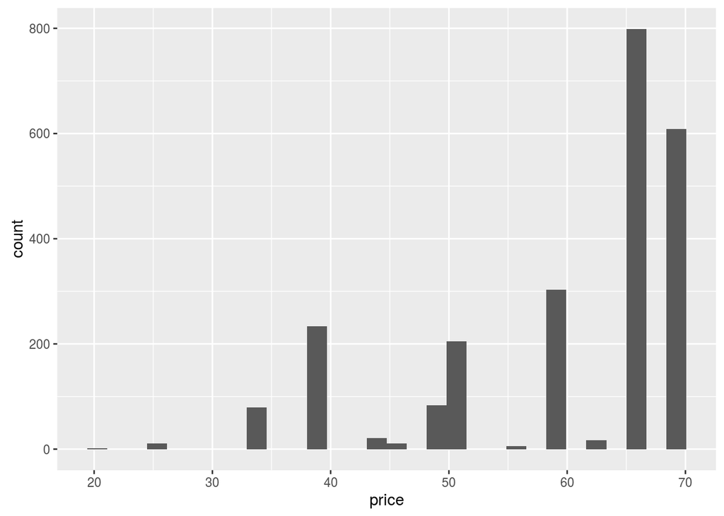

```r
qplot(x = price, data = subset(yo, !is.na(price)))
```

### Number of Purchases

Getting all number of purchases we introduce a new variable.

```r
yo <- transform(yo, all.purchases = strawberry + blueberry + pina.colada + plain + mixed.berry)
```

### Prices over Time

Notes:

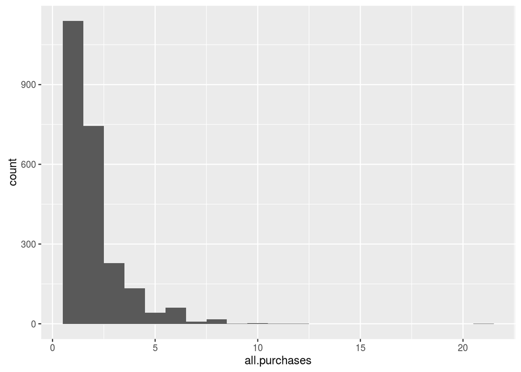

```r
qplot(x = all.purchases, data = yo, binwidth = 1)
```

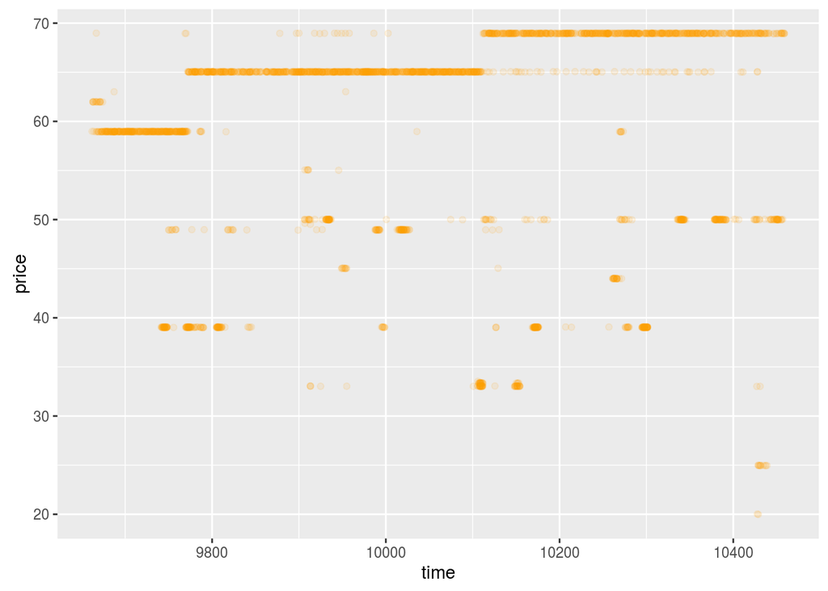

```r
ggplot(aes(x = time, y = price), data = yo) + geom_jitter(alpha = 1/10, color='orange')
```

### Sampling Observations

We sample to understand a subset better before trying to generalize it for everything.

### Looking at Samples of Households

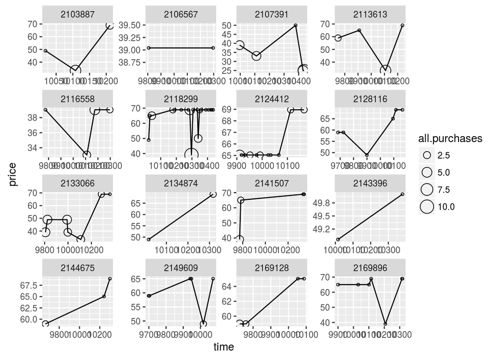

```r
library(ggplot2)
set.seed(25121992)

sample.ids <- sample(levels(yo$id),16)
ggplot(aes(time, price),data = subset(yo, yo$id %in% sample.ids)) +
  geom_line()+
  facet_wrap(~id, scales = "free")+
  geom_point(aes(size = all.purchases), pch = 1)
```

### The Limits of Cross Sectional Data

Having data at a particular instant of time is great but that does not show trends.

### Many Variables

Notes:

### Scatterplot Matrix

Let our visualizations help us find which variables to use.

```r
library(GGally)
```

[figure not shown]

```r
theme_set(theme_minimal(20))


set.seed(1836)
pf_subset <- pf[, c(2:15)]
ggpairs(pf_subset[sample.int(nrow(pf_subset), 1000), ], axisLabels = 'internal')
```

### Heat Maps

Notes:

```r
nci <- read.table("nci.tsv")
colnames(nci) <- c(1:64)
```

```r
nci.long.samp <- melt(as.matrix(nci[1:200,]))
names(nci.long.samp) <- c("gene", "case", "value")
head(nci.long.samp)
```

```
##   gene case  value
## 1    1    1  0.300
## 2    2    1  1.180
## 3    3    1  0.550
## 4    4    1  1.140
## 5    5    1 -0.265
## 6    6    1 -0.070
```

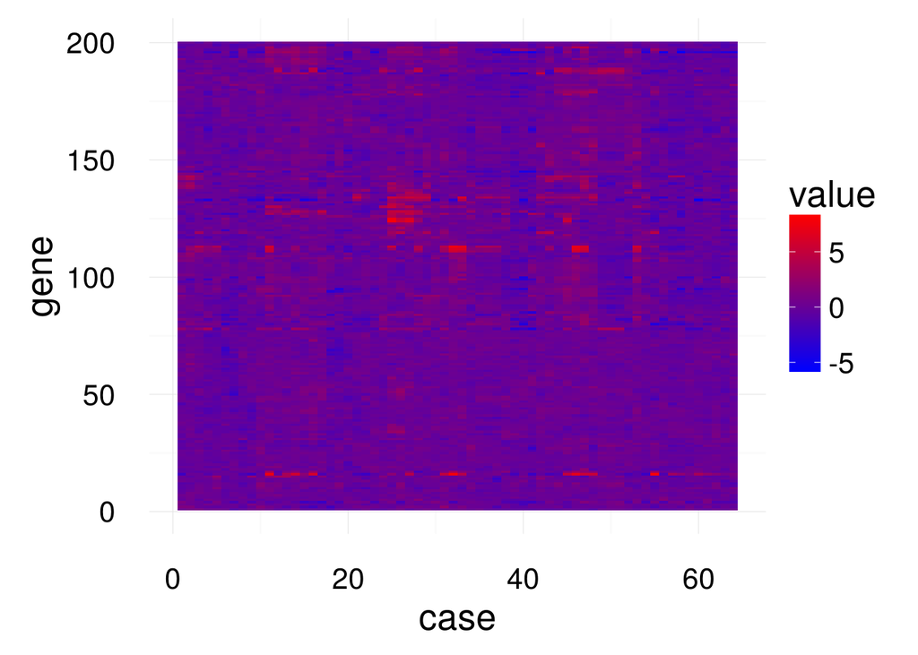

```r
ggplot(aes(y = gene, x = case, fill = value),
  data = nci.long.samp) +
  geom_tile() +
  scale_fill_gradientn(colours = colorRampPalette(c("blue", "red"))(100))
```

### Analyzing Three of More Variables

Reflection:

Click **KnitHTML** to see all of your hard work and to have an html page of this lesson, your answers, and your notes!